# Pixel classification of satellite images with artificial neural networks.

Pixel land use and land cover classification is a process of assigning specific labels or classes to each pixel in a remote sensing image, indicating the type of land use or land cover present at that location. There are several approaches to performing this classification, including supervised and unsupervised techniques.

Supervised Techniques: In supervised techniques, you need a labeled dataset, where each pixel in the image is assigned to a specific land use or land cover class. Labels can be obtained through field surveys, visual interpretation or other remote sensing techniques. Supervised classification involves training a model based on this labeled data and then using the trained model to classify new pixels.

The most common supervised techniques include machine learning algorithms such as Random Forest, Support Vector Machines (SVM), Artificial Neural Networks (ANN), and others. These algorithms use characteristics extracted from pixels, such as spectral values, textures, vegetation indices, among others, to perform the classification.

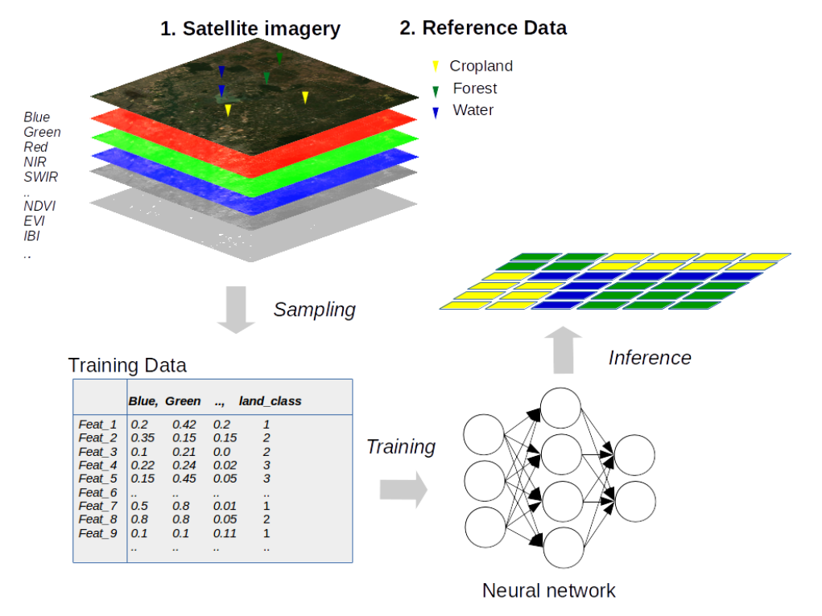

Let's use MLP to perform a pixel-by-pixel classification:

### Implementation using SkLearn

First we need to install and import the necessary packages:

```python
!pip install rasterio
```

```
     ━━━━━━━━━━━━━━━━━━━━━━━━━━━━━━━━━━━━━━━━ 21.3/21.3 MB 27.5 MB/s eta 0:00:00
```

```python
from google.colab import drive
drive.mount('/content/drive')
```

```python
import rasterio
import numpy as np
from matplotlib import pyplot as plt
import cv2
from matplotlib import cm
import pandas as pd
import seaborn as sns
import geopandas as gpd
from rasterio.plot import show
from matplotlib import pyplot as plt
from matplotlib import cm
from matplotlib.colors import ListedColormap
```

We will use a Sentinel 2 image with 10 spectral bands and with normalized values between 0 and 1:

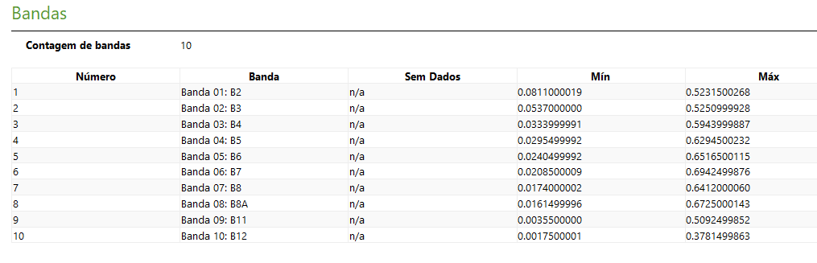

Let's use rasterio to import the image:

```python
path = '/content/drive/MyDrive/Datasets/LULC_Netherland/Netherlands_2021.tif'
```

```python
src = rasterio.open(path)
im = src.read()
```

```python
print(im.shape)
```

```
(10, 1571, 3701)
```

```python
im = im.transpose([1,2,0])
```

```python
im.shape
```

```
(1571, 3701, 10)
```

To plot, we separate the RGB bands and stack them in a new variable:

```python
R = im[:,:,2]
G = im[:,:,1]
B = im[:,:,0]
```

```python
rgb = np.dstack((R,G,B))
```

```
WARNING:matplotlib.image:Clipping input data to the valid range for imshow with RGB data ([0..1] for floats or [0..255] for integers).
```

```
(-0.5, 3700.5, 1570.5, -0.5)
```

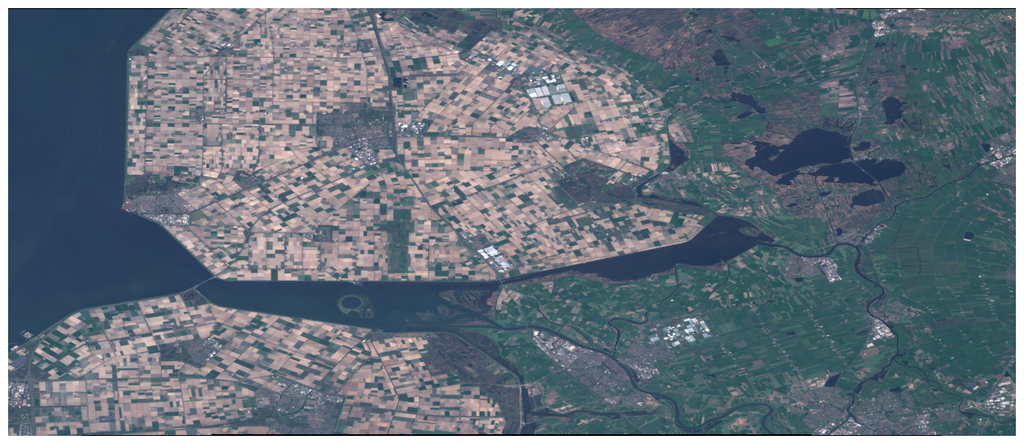

```python
plt.figure(figsize=(16,12))
plt.imshow(rgb*4)
plt.axis('off')
```

We will use points that were sampled in 5 use and coverage classes: Water, Urban, Forest, Agriculture_vegetation and Agriculture_exposed_soil:

```python
samples = gpd.read_file('/content/drive/MyDrive/Datasets/LULC_Netherland/Samples.shp')
```

```python
samples
```

|  | id | geometry |
| --- | --- | --- |
| 0 | 1 | POINT (5.53812 52.73801) |
| 1 | 1 | POINT (5.54938 52.69688) |
| 2 | 1 | POINT (5.58365 52.63372) |
| 3 | 1 | POINT (5.56897 52.73556) |
| 4 | 1 | POINT (5.56101 52.63513) |
| ... | ... | ... |
| 145 | 5 | POINT (5.95186 52.76716) |
| 146 | 5 | POINT (5.91306 52.77823) |
| 147 | 5 | POINT (5.66679 52.55724) |
| 148 | 5 | POINT (5.67285 52.56134) |
| 149 | 5 | POINT (5.72456 52.55253) |

150 rows × 2 columns

We check if the image and points are in the same coordinate system:

```python
print(samples.crs)
```

```
EPSG:4326
```

```python
print(src.crs)
```

```
EPSG:4326
```

We create a new column to add the class names:

```python
samples['label'] = samples['id'].replace({1:'Agua', 2:'Urbano', 3:'Floresta', 4:'Agricola_Vegetaçao', 5:'Agricola_Solo'})
```

```python
samples
```

|  | id | geometry | label |
| --- | --- | --- | --- |
| 0 | 1 | POINT (5.53812 52.73801) | Agua |
| 1 | 1 | POINT (5.54938 52.69688) | Agua |
| 2 | 1 | POINT (5.58365 52.63372) | Agua |
| 3 | 1 | POINT (5.56897 52.73556) | Agua |
| 4 | 1 | POINT (5.56101 52.63513) | Agua |
| ... | ... | ... | ... |
| 145 | 5 | POINT (5.95186 52.76716) | Agricola_Solo |
| 146 | 5 | POINT (5.91306 52.77823) | Agricola_Solo |
| 147 | 5 | POINT (5.66679 52.55724) | Agricola_Solo |
| 148 | 5 | POINT (5.67285 52.56134) | Agricola_Solo |
| 149 | 5 | POINT (5.72456 52.55253) | Agricola_Solo |

150 rows × 3 columns

```
WARNING:matplotlib.image:Clipping input data to the valid range for imshow with RGB data ([0..1] for floats or [0..255] for integers).
```

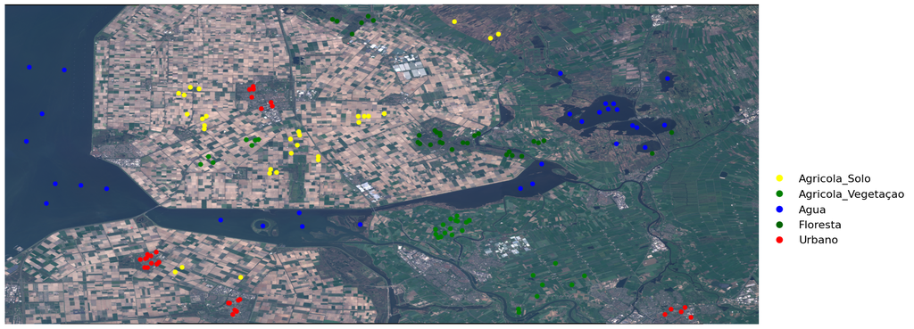

```python
cmap = ListedColormap(['yellow','green','blue','darkgreen','red'])
fig, ax = plt.subplots(figsize=(20,20))
samples.plot(column='label', categorical=True, cmap=cmap, legend=True, legend_kwds={'bbox_to_anchor':(1, 0.5),'loc':'upper left','fontsize':16,'frameon':False}, ax=ax)
ax.axis('off')
show(rgb.transpose([2,0,1])*4, transform=src.transform, ax=ax)
```

So we will create a for for each point, selecting the corresponding pixel value for each spectral band:

```python
samples['geometry']
```

```
0      POINT (5.53812 52.73801)
1      POINT (5.54938 52.69688)
2      POINT (5.58365 52.63372)
3      POINT (5.56897 52.73556)
4      POINT (5.56101 52.63513)
                 ...
145    POINT (5.95186 52.76716)
146    POINT (5.91306 52.77823)
147    POINT (5.66679 52.55724)
148    POINT (5.67285 52.56134)
149    POINT (5.72456 52.55253)
Name: geometry, Length: 150, dtype: geometry
```

```python
array_samples = []
for point in samples['geometry']:
  x = point.xy[0][0]
  y = point.xy[1][0]
  row, col = src.index(x,y)
  band_value = []
  for i in range(src.count):
    band_value.append(src.read(i+1)[row,col])
  array_samples.append(band_value)
```

At the end we convert the list to an array:

```python
X = np.array(array_samples)
```

This array will have the number of points X number of bands:

```python
X.shape
```

```
(150, 10)
```

```python
dataset = pd.DataFrame(data=X, columns=['B2','B3','B4','B5','B6','B7','B8','B8A','B11','B12'])
```

```python
dataset['label'] = samples['id']
```

```python
dataset
```

|  | B2 | B3 | B4 | B5 | B6 | B7 | B8 | B8A | B11 | B12 | label |
| --- | --- | --- | --- | --- | --- | --- | --- | --- | --- | --- | --- |
| 0 | 0.08895 | 0.06430 | 0.03805 | 0.03390 | 0.02710 | 0.02410 | 0.02085 | 0.01915 | 0.00510 | 0.00345 | 1 |
| 1 | 0.09045 | 0.06295 | 0.04010 | 0.03370 | 0.02945 | 0.02600 | 0.02240 | 0.01970 | 0.00445 | 0.00350 | 1 |
| 2 | 0.08905 | 0.06225 | 0.04045 | 0.03430 | 0.02940 | 0.02630 | 0.02235 | 0.02055 | 0.00535 | 0.00375 | 1 |
| 3 | 0.09050 | 0.06525 | 0.04105 | 0.03480 | 0.02830 | 0.02680 | 0.02175 | 0.02000 | 0.00615 | 0.00425 | 1 |
| 4 | 0.09040 | 0.06080 | 0.03865 | 0.03320 | 0.02830 | 0.02590 | 0.02095 | 0.01920 | 0.00530 | 0.00385 | 1 |
| ... | ... | ... | ... | ... | ... | ... | ... | ... | ... | ... | ... |
| 145 | 0.13585 | 0.12690 | 0.15220 | 0.16930 | 0.24035 | 0.27875 | 0.29300 | 0.32295 | 0.26210 | 0.16145 | 5 |
| 146 | 0.11155 | 0.09240 | 0.09975 | 0.12525 | 0.19760 | 0.23015 | 0.19315 | 0.26100 | 0.13890 | 0.08525 | 5 |
| 147 | 0.16380 | 0.16275 | 0.18500 | 0.19815 | 0.21450 | 0.23335 | 0.21905 | 0.24180 | 0.24210 | 0.22695 | 5 |
| 148 | 0.14335 | 0.13130 | 0.12980 | 0.15135 | 0.25745 | 0.29175 | 0.28280 | 0.30685 | 0.17595 | 0.13955 | 5 |
| 149 | 0.14075 | 0.13310 | 0.14955 | 0.16235 | 0.18070 | 0.19295 | 0.19540 | 0.20715 | 0.21625 | 0.19620 | 5 |

150 rows × 11 columns

The next step is to separate the spectral data from the target:

```python
X = dataset.iloc[:,0:-1].values
Y = dataset.iloc[:,-1].values
```

So let's import some Sklearn functions:

```python
from sklearn.model_selection import train_test_split
from sklearn.metrics import accuracy_score
from sklearn.metrics import confusion_matrix
from sklearn.preprocessing import OneHotEncoder
from sklearn.neural_network import MLPClassifier
from sklearn.metrics import classification_report
```

Since we are working with categorical data, we need to encode categorical values into binary values so that they are compatible with the expected outputs of a neural network:

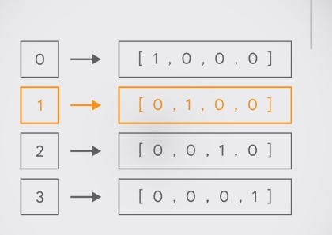

```python
new_Y = Y[:,np.newaxis]
```

```python
new_Y.shape
```

```
(150, 1)
```

```python
enc = OneHotEncoder()

enc.fit(new_Y)

onehotlabels = enc.transform(new_Y).toarray()
```

```python
onehotlabels.shape
```

```
(150, 5)
```

```python
onehotlabels
```

```
array([[1., 0., 0., 0., 0.],
       [1., 0., 0., 0., 0.],
       [1., 0., 0., 0., 0.],
       [1., 0., 0., 0., 0.],
       [1., 0., 0., 0., 0.],
       [1., 0., 0., 0., 0.],
       [1., 0., 0., 0., 0.],
       [1., 0., 0., 0., 0.],
       [1., 0., 0., 0., 0.],
       [1., 0., 0., 0., 0.],
       [1., 0., 0., 0., 0.],
       [1., 0., 0., 0., 0.],
       [1., 0., 0., 0., 0.],
       [1., 0., 0., 0., 0.],
       [1., 0., 0., 0., 0.],
       [1., 0., 0., 0., 0.],
       [1., 0., 0., 0., 0.],
       [1., 0., 0., 0., 0.],
       [1., 0., 0., 0., 0.],
       [1., 0., 0., 0., 0.],
       [1., 0., 0., 0., 0.],
       [1., 0., 0., 0., 0.],
       [1., 0., 0., 0., 0.],
       [1., 0., 0., 0., 0.],
       [1., 0., 0., 0., 0.],
       [1., 0., 0., 0., 0.],
       [1., 0., 0., 0., 0.],
       [1., 0., 0., 0., 0.],
       [1., 0., 0., 0., 0.],
       [1., 0., 0., 0., 0.],
       [0., 1., 0., 0., 0.],
       [0., 1., 0., 0., 0.],
       [0., 1., 0., 0., 0.],
       [0., 1., 0., 0., 0.],
       [0., 1., 0., 0., 0.],
       [0., 1., 0., 0., 0.],
       [0., 1., 0., 0., 0.],
       [0., 1., 0., 0., 0.],
       [0., 1., 0., 0., 0.],
       [0., 1., 0., 0., 0.],
```

[output cut: 95 more lines]

```
       [0., 0., 0., 0., 1.],
       [0., 0., 0., 0., 1.],
       [0., 0., 0., 0., 1.],
       [0., 0., 0., 0., 1.],
       [0., 0., 0., 0., 1.],
       [0., 0., 0., 0., 1.],
       [0., 0., 0., 0., 1.],
       [0., 0., 0., 0., 1.],
       [0., 0., 0., 0., 1.],
       [0., 0., 0., 0., 1.],
       [0., 0., 0., 0., 1.],
       [0., 0., 0., 0., 1.],
       [0., 0., 0., 0., 1.],
       [0., 0., 0., 0., 1.],
       [0., 0., 0., 0., 1.]])
```

We can then separate the data into training and testing:

```python
X_train, X_test, Y_train, Y_test = train_test_split(X, onehotlabels, test_size = 0.3, random_state = 42)
```

```python
classifier = MLPClassifier(hidden_layer_sizes=(16,32,8), max_iter=5000,activation = 'relu',solver='adam',random_state=1,verbose=10)
```

```python
classifier.fit(X_train, Y_train)
```

```
Iteration 1, loss = 3.87036050
Iteration 2, loss = 3.85071566
Iteration 3, loss = 3.83101681
Iteration 4, loss = 3.81124053
Iteration 5, loss = 3.79151764
Iteration 6, loss = 3.77189049
Iteration 7, loss = 3.75235660
Iteration 8, loss = 3.73289004
Iteration 9, loss = 3.71338557
Iteration 10, loss = 3.69376269
Iteration 11, loss = 3.67409729
Iteration 12, loss = 3.65444722
Iteration 13, loss = 3.63478774
Iteration 14, loss = 3.61528445
Iteration 15, loss = 3.59612260
Iteration 16, loss = 3.57791285
Iteration 17, loss = 3.56088203
Iteration 18, loss = 3.54439202
Iteration 19, loss = 3.52870800
Iteration 20, loss = 3.51382676
Iteration 21, loss = 3.49983748
Iteration 22, loss = 3.48681313
Iteration 23, loss = 3.47428713
Iteration 24, loss = 3.46232792
Iteration 25, loss = 3.45061288
Iteration 26, loss = 3.43886370
Iteration 27, loss = 3.42701062
Iteration 28, loss = 3.41497451
Iteration 29, loss = 3.40290618
Iteration 30, loss = 3.39090042
Iteration 31, loss = 3.37886731
Iteration 32, loss = 3.36678986
Iteration 33, loss = 3.35471647
Iteration 34, loss = 3.34258875
Iteration 35, loss = 3.33042126
Iteration 36, loss = 3.31820292
Iteration 37, loss = 3.30591293
Iteration 38, loss = 3.29361900
Iteration 39, loss = 3.28148536
Iteration 40, loss = 3.26931175
```

[output cut: 4256 more lines]

```
Iteration 4297, loss = 0.13722781
Iteration 4298, loss = 0.13722058
Iteration 4299, loss = 0.13711058
Iteration 4300, loss = 0.13704389
Iteration 4301, loss = 0.13697606
Iteration 4302, loss = 0.13692410
Iteration 4303, loss = 0.13684858
Iteration 4304, loss = 0.13676673
Iteration 4305, loss = 0.13668337
Iteration 4306, loss = 0.13660772
Iteration 4307, loss = 0.13651071
Iteration 4308, loss = 0.13644971
Iteration 4309, loss = 0.13642746
Iteration 4310, loss = 0.13635902
Training loss did not improve more than tol=0.000100 for 10 consecutive epochs. Stopping.
```

```
MLPClassifier(hidden_layer_sizes=(16, 32, 8), max_iter=5000, random_state=1,
              verbose=10)
```

After finishing training, let's predict the test data:

```python
y_pred = classifier.predict(X_test)
```

To then calculate the accuracy:

```python
accuracy_score(Y_test, y_pred)
```

```
0.8888888888888888
```

```python
print(classification_report(Y_test, y_pred))
```

```
              precision    recall  f1-score   support

           0       1.00      1.00      1.00        13
           1       0.86      0.67      0.75         9
           2       1.00      1.00      1.00        10
           3       1.00      1.00      1.00         4
           4       0.78      0.78      0.78         9

   micro avg       0.93      0.89      0.91        45
   macro avg       0.93      0.89      0.91        45
weighted avg       0.93      0.89      0.91        45
 samples avg       0.89      0.89      0.89        45
```

### Predicting a usage and coverage map using the trained model:

After training the model, we will apply it to an image and generate a usage and coverage map in tiff format. Let's use the same training image, with the same bands.

```python
with rasterio.open(path) as src:
    im = src.read()
```

```python
out_meta = src.meta.copy()
```

```python
im = im.transpose([1,2,0])
```

```python
X = np.nan_to_num(im)
```

```python
flatten_X = X.reshape(X.shape[0]*X.shape[1],X.shape[2])
```

```python
pred = classifier.predict(flatten_X)
```

```python
pred
```

```
array([[1, 0, 0, 0, 0],
       [1, 0, 0, 0, 0],
       [1, 0, 0, 0, 0],
       ...,
       [0, 0, 0, 1, 0],
       [0, 0, 0, 1, 0],
       [0, 0, 0, 1, 0]])
```

```python
classify = np.argmax(pred, axis=1)
```

```python
classify = classify + 1
```

```python
classify = classify.reshape(X.shape[0],X.shape[1])
```

```
(-0.5, 3700.5, 1570.5, -0.5)
```

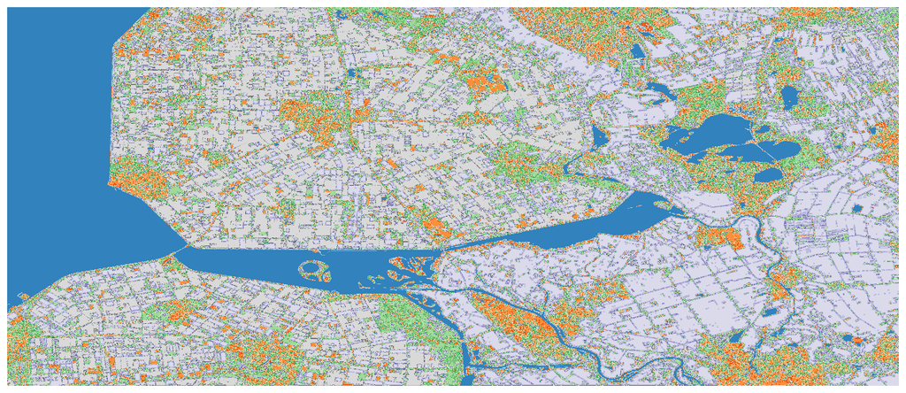

```python
plt.figure(figsize=[16,10])
plt.imshow(classify,cmap='tab20c')
plt.axis('off')
```

```python
export_image = classify[np.newaxis,:,:]
```

```python
out_meta.update({"driver": "GTiff",
                  "height": export_image.shape[1],
                  "width": export_image.shape[2],
                  "compress":'lzw',
                  "count":1
                  })
```

```python
with rasterio.open('/content/Netherlands_2020_LULC.tif', "w", **out_meta) as dest:
     dest.write(export_image)
```

# Tensorflow

[figure not shown]

TensorFlow is an open-source framework developed by Google researchers to run machine learning, deep learning, and other statistical and predictive analytics workloads. Like similar platforms, it is designed to streamline the process of developing and running advanced analytics applications for users such as data scientists, statisticians, and predictive modelers.

TensorFlow software deals with datasets that are organized as computational nodes in graph form. The edges that connect nodes in a graph can represent vectors or multidimensional matrices, creating what we call tensors. Because TensorFlow programs use a dataflow architecture that works with generalized intermediate results of calculations, they are especially open to large-scale parallel processing applications, neural networks being a common example.

The framework includes sets of high- and low-level APIs. Google recommends using high-level ones when possible to simplify data pipeline development and application programming. However, knowing how to use the low-level APIs — called TensorFlow Core — can be valuable for experimenting and debugging applications, the company says; it also gives users a "mental model" of the inner workings of machine learning technology, in Google's words.

### What is Tensor in Tensorflow?

TensorFlow, as the name implies, is a framework for defining and performing computations involving tensors. A tensor is a generalization of vectors and matrices to potentially higher dimensions. Internally, TensorFlow represents tensors as n-dimensional arrays of basic data types. Every element in Tensor has the same data type, and the data type is always known. The shape (i.e., the number of dimensions it has and the size of each dimension) may only be partially known. Most operations produce tensors of fully known shapes if the shapes of their inputs are also fully known, but in some cases it is only possible to find the shape of a tensor at graph run time.

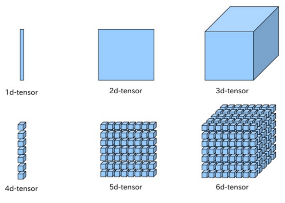

## Why use TensorFlow?

The single biggest benefit that TensorFlow offers for machine learning development is abstraction. Instead of dealing with the nitty-gritty details of implementing algorithms or figuring out suitable ways to link the output of one function to the input of another, the developer can focus on the overall logic of the application. TensorFlow takes care of the details behind the scenes.

# Keras

[figure not shown]

Keras runs on top of open source machine libraries such as TensorFlow, Theano or Cognitive Toolkit (CNTK). Theano is a Python library used for fast numerical computation tasks. TensorFlow is the most famous symbolic mathematics library used to create neural networks and deep learning models. TensorFlow is very flexible and the main benefit is distributed computing. CNTK is a deep learning framework developed by Microsoft. It uses libraries like Python, C#, C++, or standalone machine learning toolkits. Theano and TensorFlow are very powerful but difficult to understand libraries for creating neural networks.

Keras is based on a minimal framework that provides a clean and easy way to create deep learning models based on TensorFlow or Theano. Keras is designed to quickly define deep learning models. Well, Keras is an ideal choice for deep learning applications.

Keras uses various optimization techniques to make the high-level neural network API easier and more performant. It supports the following features −

- Consistent, simple and extensible API.
- Minimal structure - easy to achieve results without frills.
- Supports multiple platforms and backends.
- It is a user-friendly framework that runs on both CPU and GPU.
- High computing scalability.

### Benefits

Keras is a highly powerful and dynamic framework and has the following advantages −

- Greater community support.
- Easy to test.
- Keras neural networks are written in Python, which makes things simpler.
- Keras supports convolution and recurrent networks.
- Deep learning models are discrete components, so you can combine them in many ways.

Let's use Keras integrated with tensorflow:

Given that TensorFlow was the de facto standard backend for the Keras open source project, the integration means that a single library can now be used instead of two separate libraries. Additionally, the independent Keras project now recommends that all future Keras developments use the tf.keras API.

```python
from google.colab import drive
drive.mount('/content/drive')
```

```python
import numpy as np
from matplotlib import pyplot as plt
import cv2
from matplotlib import cm
import pandas as pd
import seaborn as sns
from matplotlib import pyplot as plt
from matplotlib import cm
from matplotlib.colors import ListedColormap
import geopandas as gpd
from sklearn.model_selection import train_test_split
from sklearn.preprocessing import OneHotEncoder
from sklearn.metrics import classification_report
from sklearn.metrics import confusion_matrix
```

```python
from tensorflow import keras
from tensorflow.keras.models import Sequential
from tensorflow.keras.layers import Dense
```

```python
samples = gpd.read_file('/content/drive/MyDrive/Datasets/LULC_Pixel_Classification/classes_de_uso.shp')
```

```python
samples
```

|  | B11 | classe | B12 | B8A | label | B1 | B2 | rand | B3 | random | B4 | B5 | B6 | B7 | B8 | B9 | geometry |
| --- | --- | --- | --- | --- | --- | --- | --- | --- | --- | --- | --- | --- | --- | --- | --- | --- | --- |
| 0 | 0.11060 | 3 | 0.04925 | 0.34265 | agricultura | 0.01640 | 0.02725 | 0.999976 | 0.05925 | 0.990412 | 0.03110 | 0.10555 | 0.25665 | 0.32045 | 0.32960 | 0.37570 | POINT (-51.90767 -29.70724) |
| 1 | 0.12030 | 3 | 0.05790 | 0.29270 | agricultura | 0.01665 | 0.02035 | 0.999933 | 0.03345 | 0.054960 | 0.02090 | 0.05785 | 0.19675 | 0.27700 | 0.21795 | 0.35335 | POINT (-51.96534 -29.61651) |
| 2 | 0.14800 | 3 | 0.07730 | 0.37535 | agricultura | 0.02515 | 0.04140 | 0.999918 | 0.08090 | 0.610448 | 0.06920 | 0.15110 | 0.27670 | 0.33200 | 0.32470 | 0.36825 | POINT (-51.91476 -29.72386) |
| 3 | 0.16370 | 3 | 0.10150 | 0.34395 | agricultura | 0.02620 | 0.04200 | 0.999899 | 0.08415 | 0.009023 | 0.07935 | 0.15470 | 0.26035 | 0.31145 | 0.33460 | 0.31360 | POINT (-51.91099 -29.71236) |
| 4 | 0.12560 | 3 | 0.06400 | 0.35155 | agricultura | 0.02160 | 0.03355 | 0.999895 | 0.06595 | 0.347600 | 0.04990 | 0.12265 | 0.26420 | 0.31950 | 0.31360 | 0.35290 | POINT (-51.90767 -29.71272) |
| ... | ... | ... | ... | ... | ... | ... | ... | ... | ... | ... | ... | ... | ... | ... | ... | ... | ... |
| 4995 | 0.34995 | 2 | 0.27430 | 0.25040 | solo_exposto | 0.05200 | 0.05640 | 0.954984 | 0.07990 | 0.986132 | 0.09175 | 0.13375 | 0.18910 | 0.21780 | 0.22310 | 0.26125 | POINT (-51.93111 -29.71227) |
| 4996 | 0.33655 | 2 | 0.24140 | 0.26275 | solo_exposto | 0.05255 | 0.07705 | 0.954976 | 0.10610 | 0.858527 | 0.14510 | 0.17850 | 0.19920 | 0.22540 | 0.23440 | 0.26600 | POINT (-51.77894 -29.79348) |
| 4997 | 0.35550 | 2 | 0.30085 | 0.28730 | solo_exposto | 0.05565 | 0.05985 | 0.954880 | 0.08320 | 0.503585 | 0.10155 | 0.17590 | 0.23170 | 0.25520 | 0.23840 | 0.28280 | POINT (-51.77957 -29.78935) |
| 4998 | 0.32695 | 2 | 0.20510 | 0.26720 | solo_exposto | 0.04175 | 0.05025 | 0.954838 | 0.07265 | 0.280611 | 0.07485 | 0.12135 | 0.20115 | 0.23260 | 0.23200 | 0.26075 | POINT (-51.77948 -29.79150) |
| 4999 | 0.31495 | 2 | 0.21080 | 0.30215 | solo_exposto | 0.05320 | 0.07360 | 0.954777 | 0.10425 | 0.767035 | 0.14460 | 0.16560 | 0.22965 | 0.25620 | 0.27530 | 0.29205 | POINT (-51.81101 -29.80471) |

5000 rows × 17 columns

```python
samples.columns
```

```
Index(['B11', 'classe', 'B12', 'B8A', 'label', 'B1', 'B2', 'rand', 'B3',
       'random', 'B4', 'B5', 'B6', 'B7', 'B8', 'B9', 'geometry'],
      dtype='object')
```

```python
X = samples[['B12', 'B8A', 'B2', 'B3', 'B4', 'B5', 'B6', 'B7', 'B8']].values
Y = samples['classe'].values
```

```python
Y = Y[:,np.newaxis]
```

```python
Y.shape
```

```
(5000, 1)
```

```python
enc = OneHotEncoder()

enc.fit(Y)

Y = enc.transform(Y).toarray()
```

```python
Y.shape
```

```
(5000, 5)
```

```python
Y
```

```
array([[0., 0., 0., 1., 0.],
       [0., 0., 0., 1., 0.],
       [0., 0., 0., 1., 0.],
       ...,
       [0., 0., 1., 0., 0.],
       [0., 0., 1., 0., 0.],
       [0., 0., 1., 0., 0.]])
```

```python
X_train, X_test, Y_train, Y_test = train_test_split(X, Y, test_size = 0.3, random_state = 42)
```

Now let's define the size of the input shape and the number of classes we have:

```python
input_shape = (X_train.shape[1:])
num_classes = len(np.unique(samples['classe'].values))
```

```python
input_shape
```

```
(9,)
```

```python
num_classes
```

```
5
```

So let's build our neural network by adding the dense layers:

```python
model = Sequential()
model.add(Dense(128, input_shape=input_shape, activation='relu'))
model.add(Dense(32, activation='relu'))
model.add(Dense(8, activation='relu'))
model.add(Dense(num_classes, activation='softmax'))
```

In the input layer and hidden layers we use the relu activation function. Since we are dealing with a multi-class classification problem, we will use the softmax enable function in the output layer.

Now we can compile the model, defining the loss as categorical entropy, the Adam optimizer, and the validation metric as accuracy:

```python
model.compile(loss='categorical_crossentropy', optimizer='adam', metrics=['accuracy'])
```

```python
model.summary()
```

```
Model: "sequential"
_________________________________________________________________
 Layer (type)                Output Shape              Param #
=================================================================
 dense (Dense)               (None, 128)               1280

 dense_1 (Dense)             (None, 32)                4128

 dense_2 (Dense)             (None, 8)                 264

 dense_3 (Dense)             (None, 5)                 45

=================================================================
Total params: 5,717
Trainable params: 5,717
Non-trainable params: 0
_________________________________________________________________
```

```python
history = model.fit(X_train, Y_train, epochs=300, batch_size=250, verbose=1, validation_split=0.2)
```

Let's plot the loss and accuracy graphs per epoch for the training and validation data:

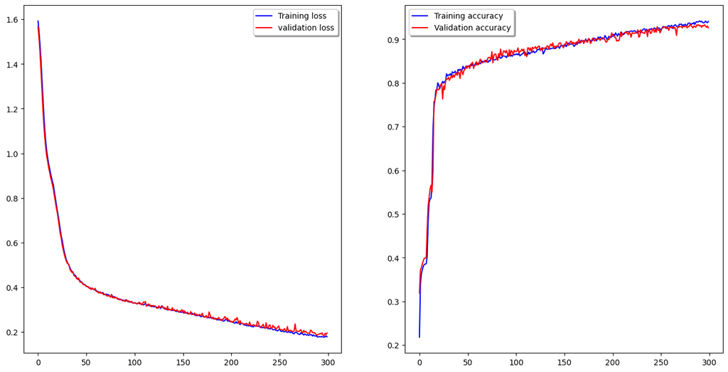

```python
fig, ax = plt.subplots(1,2, figsize=(16,8))
ax[0].plot(history.history['loss'], color='b', label="Training loss")
ax[0].plot(history.history['val_loss'], color='r', label="validation loss",axes =ax[0])
legend = ax[0].legend(loc='best', shadow=True)

ax[1].plot(history.history['accuracy'], color='b', label="Training accuracy")
ax[1].plot(history.history['val_accuracy'], color='r',label="Validation accuracy")
legend = ax[1].legend(loc='best', shadow=True)
```

```python
score = model.evaluate(X_test, Y_test, verbose=0)
print('Test loss:', score[0])
print('Test accuracy:', score[1])
```

```
Test loss: 0.20278969407081604
Test accuracy: 0.921999990940094
```

```python
y_pred = model.predict(X_test)
```

```python
y_pred_res = np.argmax(y_pred, axis=1)
```

```python
Y_test_res = np.argmax(Y_test, axis=1)
```

```python
print(classification_report(Y_test_res, y_pred_res))
```

```
              precision    recall  f1-score   support

           0       0.98      0.99      0.98       284
           1       0.86      0.97      0.91       309
           2       0.87      0.94      0.91       290
           3       0.95      0.85      0.90       316
           4       0.97      0.86      0.92       301

    accuracy                           0.92      1500
   macro avg       0.93      0.92      0.92      1500
weighted avg       0.93      0.92      0.92      1500
```

# Dropout

Dropout is a regularization method that approximates the training of a large number of neural networks with different architectures in parallel.

During training, some layer outputs are randomly ignored or "dropped". This has the effect of making the layer look and feel like a layer with a different number of nodes and connectivity to the previous layer. In effect, each update of a layer during training is performed with a different “view” of the configured layer.

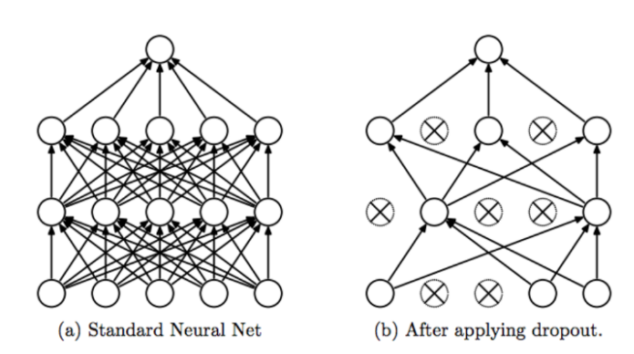

## Batch Normalization

Normalization is a data preprocessing tool used to bring numerical data to a common scale without distorting its shape.

Generally, when we input data into a deep learning machine or algorithm, we tend to change the values to a balanced scale. The reason we normalize is, in part, to ensure that our model can generalize properly.

Now coming back to batch normalization, it is a process to make neural networks faster and more stable by adding extra layers in a deep neural network. The new layer performs standardization and normalization operations on the input of a layer from a previous layer.

But what is the reason behind the term “Batch” in batch normalization? A typical neural network is trained using a collected set of input data called a batch. Similarly, the normalization process in batch normalization occurs in batches, not as a single input.

```python
from tensorflow.keras.layers import Dropout, BatchNormalization
```

Let's then add a dropout and batch normalization layer between the dense layers and see how the model behaves:

```python
model_2 = Sequential()
model_2.add(Dense(128, input_shape=input_shape, activation='relu'))
model_2.add(Dropout(0.1))
model_2.add(BatchNormalization())
model_2.add(Dense(32, activation='relu'))
model_2.add(Dropout(0.1))
model_2.add(Dense(8, activation='relu'))
model_2.add(Dropout(0.1))
model_2.add(Dense(num_classes, activation='softmax'))
```

```python
model_2.compile(loss='categorical_crossentropy', optimizer='adam', metrics=['accuracy'])
```

```python
model_2.summary()
```

```
Model: "sequential_1"
_________________________________________________________________
 Layer (type)                Output Shape              Param #
=================================================================
 dense_4 (Dense)             (None, 128)               1280

 dropout (Dropout)           (None, 128)               0

 batch_normalization (BatchN  (None, 128)              512
 ormalization)

 dense_5 (Dense)             (None, 32)                4128

 dropout_1 (Dropout)         (None, 32)                0

 dense_6 (Dense)             (None, 8)                 264

 dropout_2 (Dropout)         (None, 8)                 0

 dense_7 (Dense)             (None, 5)                 45

=================================================================
Total params: 6,229
Trainable params: 5,973
Non-trainable params: 256
_________________________________________________________________
```

Let's train the model:

```python
history2 = model_2.fit(X_train, Y_train, epochs=300, batch_size=250, verbose=1, validation_split=0.2)
```

Next, let's plot the loss and accuracy curves:

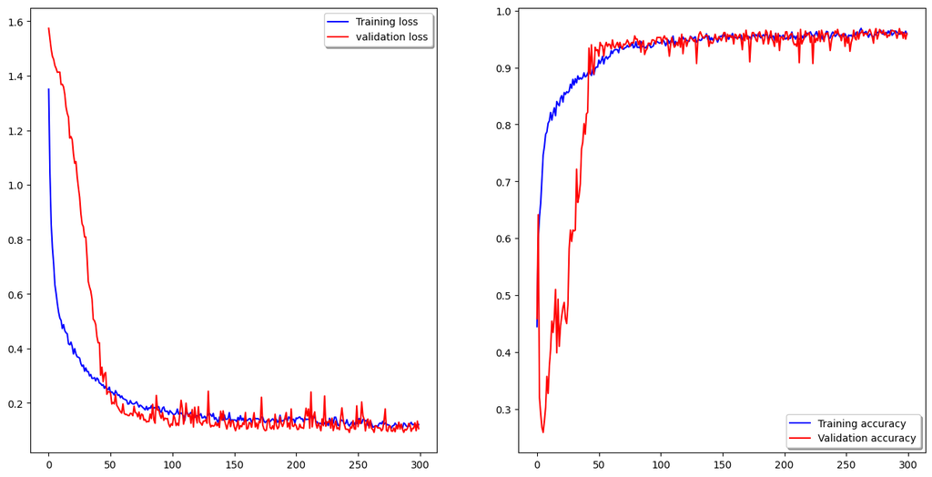

```python
fig, ax = plt.subplots(1,2, figsize=(16,8))
ax[0].plot(history2.history['loss'], color='b', label="Training loss")
ax[0].plot(history2.history['val_loss'], color='r', label="validation loss",axes =ax[0])
legend = ax[0].legend(loc='best', shadow=True)

ax[1].plot(history2.history['accuracy'], color='b', label="Training accuracy")
ax[1].plot(history2.history['val_accuracy'], color='r',label="Validation accuracy")
legend = ax[1].legend(loc='best', shadow=True)
```

```python
y_pred_2 = model_2.predict(X_test)
```

```python
y_pred_res2 = np.argmax(y_pred_2, axis=1)
```

```python
Y_test_res2 = np.argmax(Y_test, axis=1)
```

```python
print(classification_report(y_pred_res2, Y_test_res2))
```

```
              precision    recall  f1-score   support

           0       1.00      0.98      0.99       290
           1       0.98      0.96      0.97       315
           2       0.93      0.95      0.94       284
           3       0.97      0.97      0.97       315
           4       0.95      0.96      0.95       296

    accuracy                           0.96      1500
   macro avg       0.96      0.96      0.96      1500
weighted avg       0.96      0.96      0.96      1500
```

```python
c_matrix = confusion_matrix(Y_test_res2, y_pred_res2)
```

```python
names = ['Agua','Vegetação','Solo','Agricultura','Infra_urbana']
```

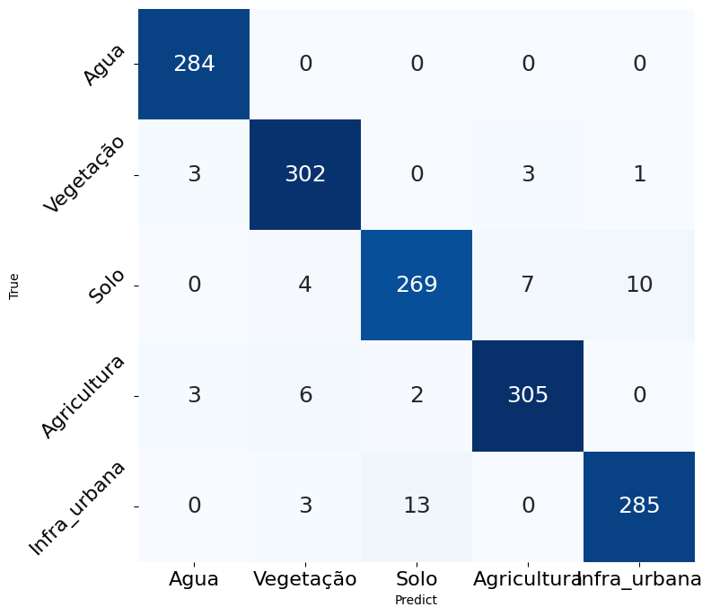

```python
r1 = pd.DataFrame(data=c_matrix, index= names, columns=names)
fig, ax = plt.subplots(figsize=(8,8))
ax = sns.heatmap(r1, annot=True, annot_kws={"size": 18},fmt='d',cmap="Blues", cbar = False)
#for t in ax.texts: t.set_text(t.get_text() + " %")
ax.tick_params(labelsize=16)
ax.set_yticklabels(names, rotation=45)
ax.set_ylabel('True')
ax.set_xlabel('Predict')
```